# Лабораторная работа №16

Программный RAID

Максат Хемраев

Российский университет дружбы народов, Москва, Россия

03 декабря 2025

# Цель работы

## Основная цель

Освоить создание и администрирование RAID-массивов в Linux с использованием утилиты **mdadm**.

# Ход выполнения работы

## Подготовка дисков

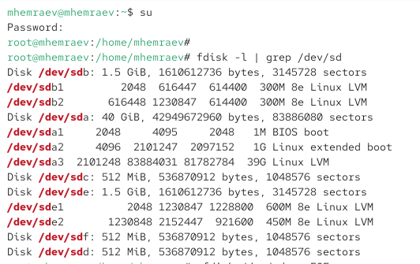

Просмотр дисков

## Настройка разделов под RAID

- Проверен тип созданных партиций (тип 83)
- Найден тип для RAID — **fd (Linux raid autodetect)**
- Тип изменён на fd для всех трёх дисков

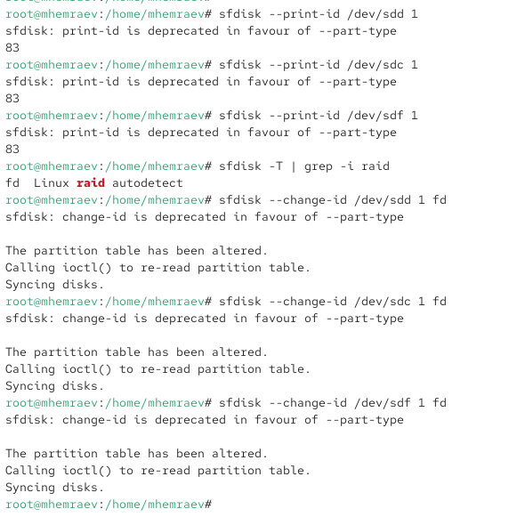

Изменение типа партиций

## Проверка структуры разделов

- Каждый диск содержит один раздел с типом RAID
- Разметка отображается корректно

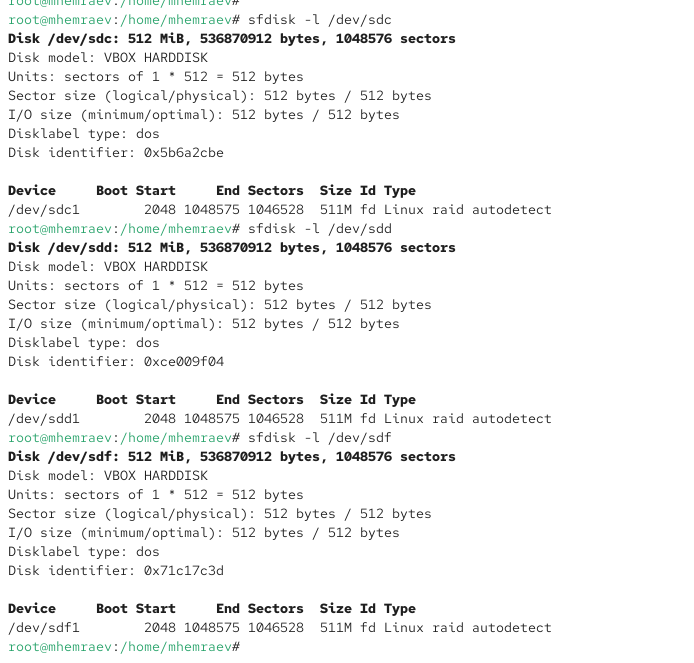

Состояние дисков

# Создание RAID 1

## Сборка RAID1

- Создан массив из /dev/sdc1 и /dev/sdd1
- Успешно инициализирован

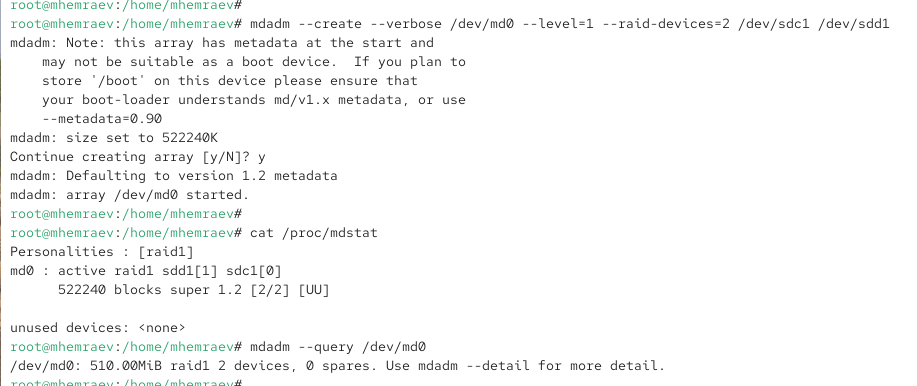

Создание RAID1

## Проверка состояния RAID1

- Оба диска активны и синхронизированы
- Ошибок нет

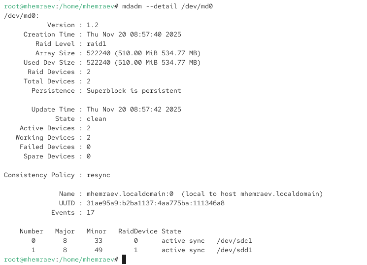

Проверка RAID

## Создание файловой системы и монтирование

- Создана файловая система ext4
- RAID смонтирован в `/mnt/raid`
- Добавлена запись в `/etc/fstab`

[figure not shown]

fstab запись

# Замена диска в RAID1

## Симуляция сбоя

- Сбой инициирован на /dev/sdc1
- Диск удалён из массива

## Добавление нового диска

- В массив добавлен /dev/sdf1
- Массив восстановлен и синхронизирован

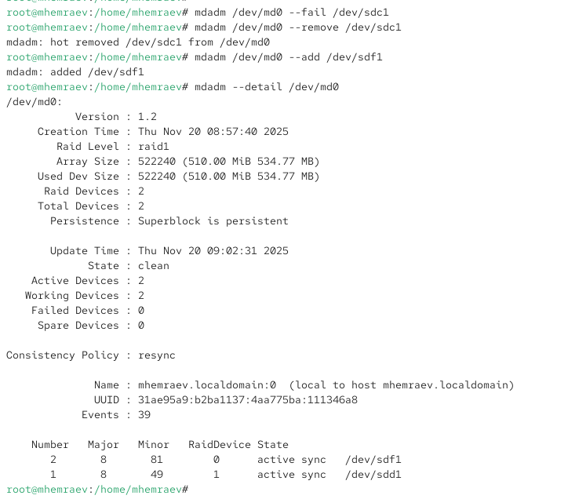

Восстановление RAID

## Очистка суперблоков

- RAID остановлен
- Метаданные удалены с дисков

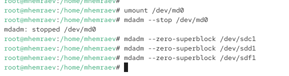

Очистка суперблоков

# RAID1 с горячим резервом

## Создание RAID1 и добавление hot spare

- Массив создан на двух дисках
- Третий диск /dev/sdf1 добавлен как резервный

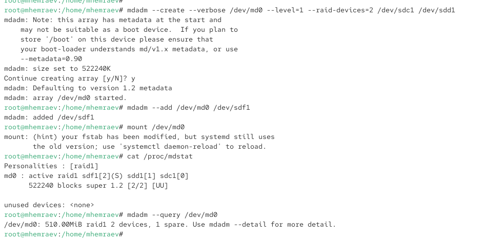

Hot spare

## Проверка работы hot spare

- При сбое одного диска  
  массив автоматически использует резервный

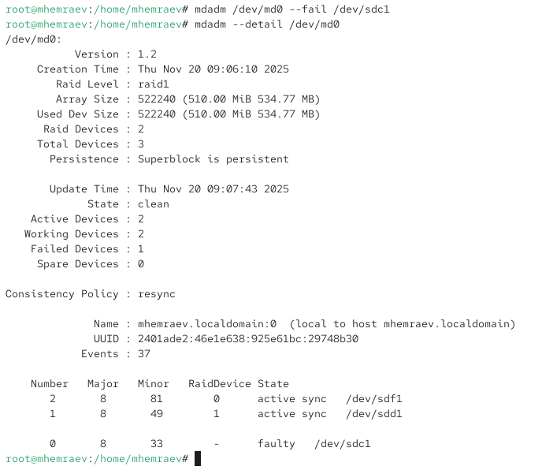

Пересборка массива

# Преобразование RAID1 → RAID5

## Подготовка массива

- RAID1 создан снова
- Добавлен третий диск (spare)

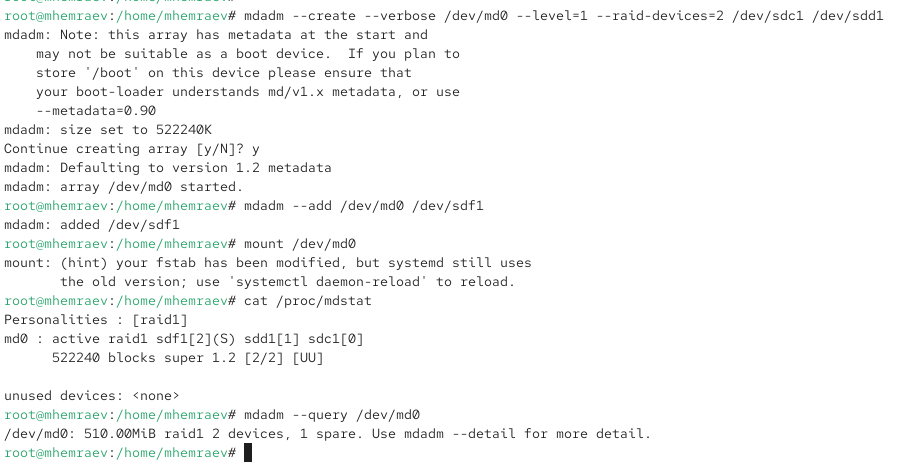

Перед конверсией

## Изменение уровня RAID

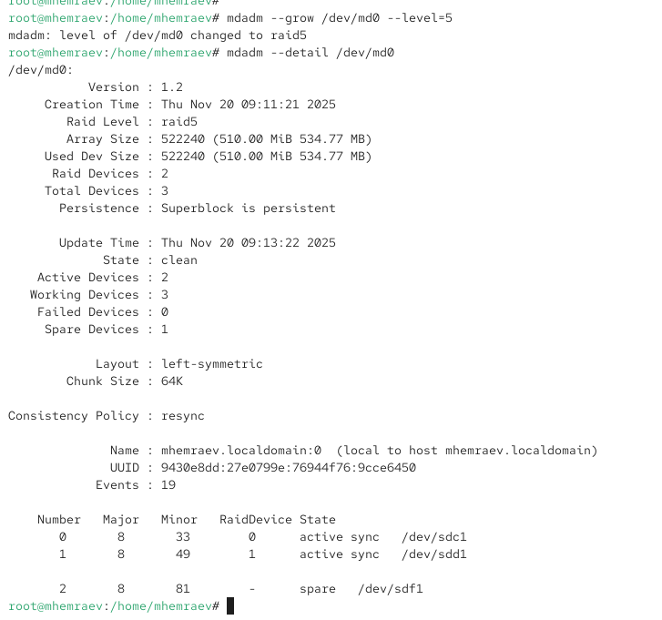

Преобразование RAID

## Увеличение количества дисков

- RAID расширен до трёх устройств
- Пересборка выполняется корректно

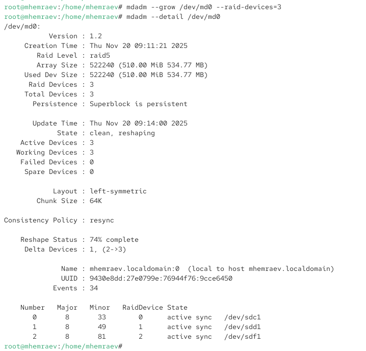

RAID5 пересборка

# Итоги работы

## Вывод

В ходе работы освоены:

- создание RAID 1
- использование горячего резерва
- преобразование массива RAID 1 в RAID 5
- работа с утилитой **mdadm**, анализ состояния и восстановление массива

Получены практические навыки администрирования систем хранения данных и обеспечения отказоустойчивости.